# ECO602- Using Models Activity

Mercy Melo

11/4/2021

# Question 1

Create a histogram of the salamander reproduction catastrophic rates.

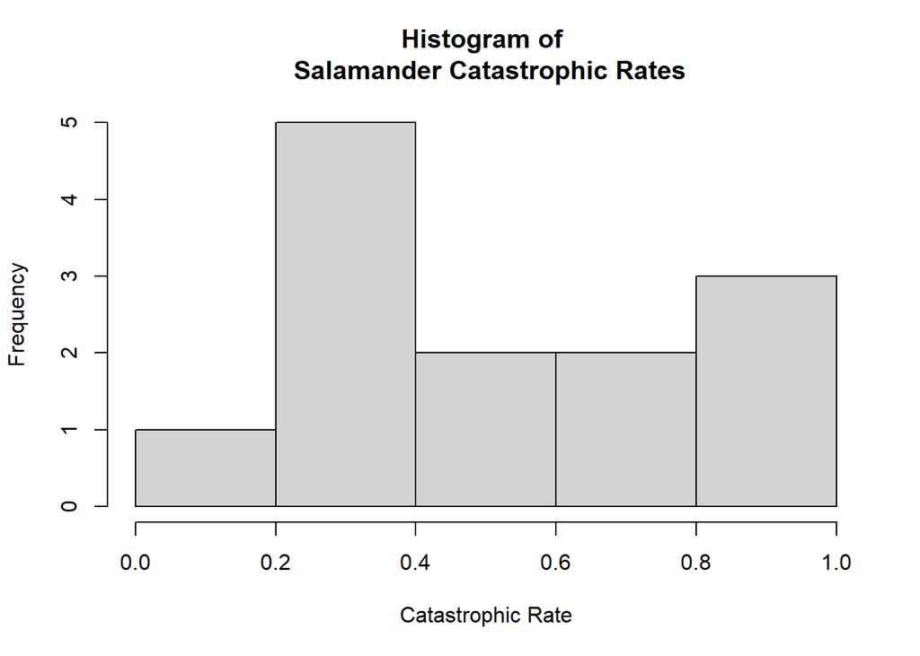

```r
hist(catrate$cat.rate,
     main = "Histogram of \n Salamander Catastrophic Rates",
     xlab = "Catastrophic Rate")
```

# Question 2

Conduct a Shapiro-Wilk test of normality of the salamander catastrophic rates. Report the p-value and show the R-code you used to conduct the test.

p = 0.04097

```r
shapiro.test(catrate$cat.rate)
```

```
##
##  Shapiro-Wilk normality test
##
## data:  catrate$cat.rate
## W = 0.86202, p-value = 0.04097
```

# Question 3

What is the null hypothesis for the Shapiro test?

The null hypothesis of the Shapiro test is that the data are normally-distributed.

# Question 4

Based on the Shapiro test results, is there strong evidence that the sample came from a non-normally-distributed population?

Yes, the data seem to be from a non-normally-distributed population since the p value was less than the significance threshold of 0.05.

# Question 5

Show the code you used to conduct the t-test.

```r
t.test(catrate$cat.rate, mu = 0.28)
```

```
##
##  One Sample t-test
##
## data:  catrate$cat.rate
## t = 3.0261, df = 12, p-value = 0.01054
## alternative hypothesis: true mean is not equal to 0.28
## 95 percent confidence interval:
##  0.3526250 0.7261295
## sample estimates:
## mean of x
## 0.5393773
```

# Question 6

State the null hypothesis of the test, in plain nontechnical English.

The null hypothesis is that the catastrophe rate (or the proportion of years where there are less than 1 offspring produced per breeding female) is the same as the late-fill rate (or the proportion of times the vernal pools filled later than normal).

# Question 7

Is this a one- or two-tailed test?

This is a two-tailed test because the catastrophe rate can be higher or lower than the late-fill rate.

# Question 8

What is the p-value from your t-test? Interpret the p-value as a false-positive rate using nontechnical English that a non-scientist would understand.

The p-value from this test was 0.01, which means that if we replicated this experiment 100 times, we’d wrongly conclude that there was a difference between the two rates once. In other words, we have a 1% chance of being incorrect when deciding that there is a difference between the catastrophe rate and the late-fill rate.

# Question 9

What is the confidence interval for the difference between the null hypothesis and alternative hypothesis means? Did it include zero?

CI = 0.3526250 0.7261295 This confidence interval does not include zero, which indicates that we can be 95% certain that our difference in the two rates is larger than zero.

# Question 10

Considering the results from your t-test, did you conclude that there was strong evidence to reject the null hypothesis?

Yes, the p-value (0.01) was below our alpha significance level of 0.05, indicating that there is a significant difference between the 2 rates.

# Question 11

Show the code you used to conduct the test.

```r
wilcox.test(catrate$cat.rate, mu = 0.28)
```

```
##
##  Wilcoxon signed rank test with continuity correction
##
## data:  catrate$cat.rate
## V = 85, p-value = 0.006275
## alternative hypothesis: true location is not equal to 0.28
```

# Question 12

Compare the p-value with the p-value you got from the t-test.

The p-value from the Wilcoxon rank sum test (0.006) was less than the p-value from the t-test (0.01).

# Question 13

Considering the results from your rank sum test, did you conclude that there was strong evidence to reject the null hypothesis?

Yes, because the p-value (0.006) was less than the alpha significance value of 0.05, we can reject the null hypothesis.

# Question 14

Compare the overall conclusions you could draw from the results of the two tests.

Both tests suggested that the catastrophe rate was significantly different from the late-fill rate.

# Question 15

Considering the numerical and graphical data exploration, which test do you think was more appropriate for these data?

The Wilcoxon rank sum test would be the more appropriate choice for this analysis because our data were not normally-distributed (a key assumption of the t-test).

# Question 16

Show the R-code you used to conduct tests of normality for the flipper lengths of Chinstrap and Adelie penguins.

```r
require(palmerpenguins)
penguin_adelie = droplevels(subset(penguins, species == "Adelie"))
penguin_chinstrap = droplevels(subset(penguins, species == "Chinstrap"))

shapiro.test(penguin_adelie$flipper_length_mm)
```

```
##
##  Shapiro-Wilk normality test
##
## data:  penguin_adelie$flipper_length_mm
## W = 0.99339, p-value = 0.72
```

```r
shapiro.test(penguin_chinstrap$flipper_length_mm)
```

```
##
##  Shapiro-Wilk normality test
##
## data:  penguin_chinstrap$flipper_length_mm
## W = 0.98891, p-value = 0.8106
```

# Question 17

Interpret the test results. Do you conclude that the flipper lengths are normally-distributed for each species?

Yes, the flipper lengths of both penguin species are normally-distributed because the p-values from both tests were greater than the alpha significance value of 0.05.

# Question 18

Create a single figure consisting of histograms of flipper lengths of Adelie and Chinstrap penguins.

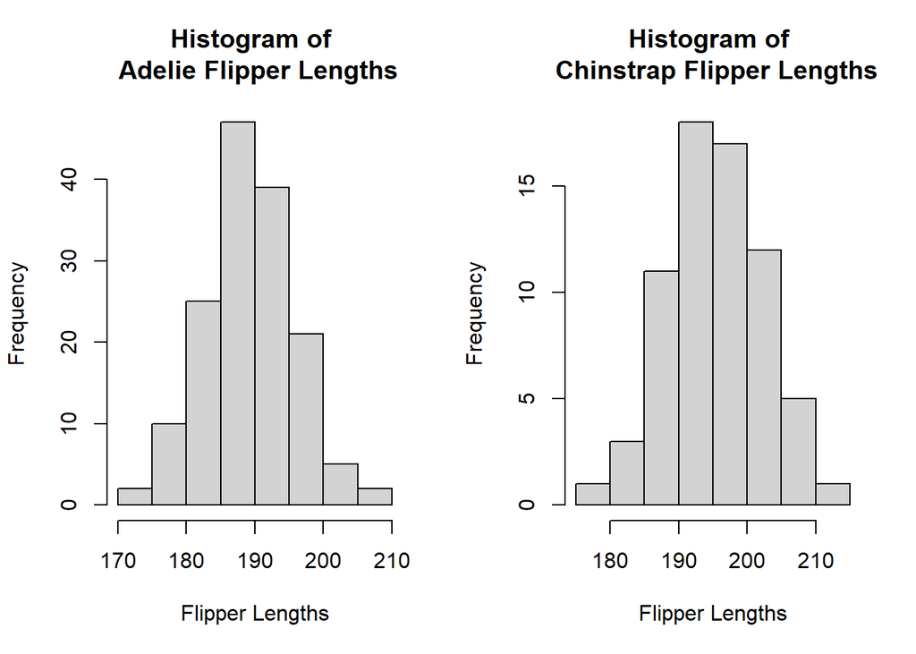

```r
par(mfrow = c(1,2))
hist(penguin_adelie$flipper_length_mm, main = "Histogram of \n Adelie Flipper Lengths", xlab = "Flipper Lengths")
hist(penguin_chinstrap$flipper_length_mm, main = "Histogram of \n Chinstrap Flipper Lengths", xlab = "Flipper Lengths")
```

# Question 19

State the alternative hypothesis of the test, in plain nontechnical English.

The alternative hypothesis is that the two species of penguins have different flipper lengths from one another.

# Question 20

Include the code you used to conduct the t-test.

```r
t.test(penguin_adelie$flipper_length_mm, penguin_chinstrap$flipper_length_mm)
```

```
##
##  Welch Two Sample t-test
##
## data:  penguin_adelie$flipper_length_mm and penguin_chinstrap$flipper_length_mm
## t = -5.7804, df = 119.68, p-value = 6.049e-08
## alternative hypothesis: true difference in means is not equal to 0
## 95 percent confidence interval:
##  -7.880530 -3.859244
## sample estimates:
## mean of x mean of y
##  189.9536  195.8235
```